# Infer ASVs with DADA2

# Remove Chimeras

```r
# Remove the chimeras in the raw ASV table
noChimeras_ASV_table <- removeBimeraDenovo(raw_ASV_table_trimmed,
                                           method="consensus",
                                           multithread=5, verbose=TRUE)
```

```
## Identified 48835 bimeras out of 80453 input sequences.
```

```r
# Check the dimensions
dim(noChimeras_ASV_table)
```

```
## [1]    36 31618
```

```r
# What proportion is left of the sequences?
sum(noChimeras_ASV_table)/sum(raw_ASV_table_trimmed)
```

```
## [1] 0.81274
```

```r
sum(noChimeras_ASV_table)/sum(raw_ASV_table)
```

```
## [1] 0.8113012
```

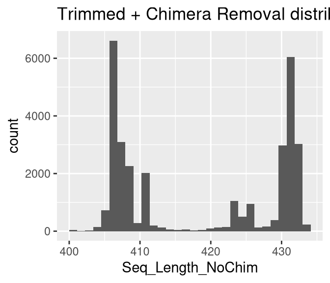

```r
# Plot it
data.frame(Seq_Length_NoChim = nchar(getSequences(noChimeras_ASV_table))) %>%
  ggplot(aes(x = Seq_Length_NoChim )) +
  geom_histogram()+
  labs(title = "Trimmed + Chimera Removal distribution of ASV length")
```

# Track the read counts

```r
# Function to identify number seqs
getN <- function(x) sum(getUniques(x))

# Make the table to track the seqs
track <- cbind(filtered_reads,
               sapply(dada_forward, getN),
               sapply(dada_reverse, getN),
               sapply(merged_ASVs, getN),
               rowSums(noChimeras_ASV_table))
head(track)
```

```
##                        reads.in reads.out
## SRR21916202_1.fastq.gz    84301     72757 63336 65789 35826 29386
## SRR21916203_1.fastq.gz    90262     78653 70184 72774 46001 38767
## SRR21916204_1.fastq.gz    93980     81179 72022 74619     0     0
## SRR21916205_1.fastq.gz    98609     85375 77532 79587 50008 42868
## SRR21916206_1.fastq.gz    98699     85615 76055 78373 45951 37728
## SRR21916207_1.fastq.gz    95172     82622 72670 75130 42658 35255
```

```r
# Update column names to be more informative (most are missing at the moment!)
colnames(track) <- c("input", "filtered", "denoisedF", "denoisedR", "merged", "nochim")
rownames(track) <- samples

# Generate a dataframe to track the reads through our DADA2 pipeline
track_counts_df <-
  track %>%
  # make it a dataframe
  as.data.frame() %>%
  rownames_to_column(var = "names") %>%
  mutate(perc_reads_retained = 100 * nochim / input)

# Visualize it in table format
DT::datatable(track_counts_df)
```

|  | names | input | filtered | denoisedF | denoisedR | merged | nochim | perc_reads_retained |
| --- | --- | --- | --- | --- | --- | --- | --- | --- |
| 1 | SRR21916202 | 84301 | 72757 | 63336 | 65789 | 35826 | 29386 | 34.85842398073569 |
| 2 | SRR21916203 | 90262 | 78653 | 70184 | 72774 | 46001 | 38767 | 42.94941392834194 |
| 3 | SRR21916204 | 93980 | 81179 | 72022 | 74619 | 0 | 0 | 0 |
| 4 | SRR21916205 | 98609 | 85375 | 77532 | 79587 | 50008 | 42868 | 43.47270533115638 |
| 5 | SRR21916206 | 98699 | 85615 | 76055 | 78373 | 45951 | 37728 | 38.22531130001317 |
| 6 | SRR21916207 | 95172 | 82622 | 72670 | 75130 | 42658 | 35255 | 37.04345815996302 |
| 7 | SRR21916208 | 92237 | 79185 | 69693 | 72204 | 39858 | 30898 | 33.49848759174735 |
| 8 | SRR21916209 | 90299 | 77582 | 69753 | 71135 | 40935 | 32487 | 35.97714260401555 |
| 9 | SRR21916210 | 84743 | 73197 | 64334 | 66341 | 36406 | 29017 | 34.24117626234615 |
| 10 | SRR21916211 | 98661 | 84368 | 75390 | 77946 | 46807 | 35841 | 36.32742421017424 |

[output cut: 26 more lines]

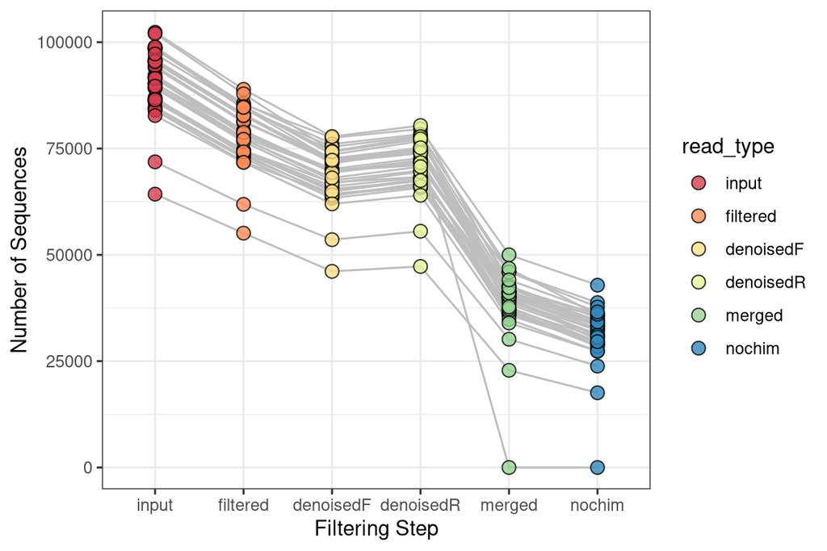

```r
# Plot it!
track_counts_df %>%
  pivot_longer(input:nochim, names_to = "read_type", values_to = "num_reads") %>%
  mutate(read_type = fct_relevel(read_type,
                                 "input", "filtered", "denoisedF", "denoisedR", "merged", "nochim")) %>%
  ggplot(aes(x = read_type, y = num_reads, fill = read_type)) +
  geom_line(aes(group = names), color = "grey") +
  geom_point(shape = 21, size = 3, alpha = 0.8) +
  scale_fill_brewer(palette = "Spectral") +
  labs(x = "Filtering Step", y = "Number of Sequences") +
  theme_bw()
```

# Assign Taxonomy

Here, we will use the Silva database version 138! This differs from the workflow of the authors who own this data, who used The Greengenes database Release 13.8.

```r
# Classify the ASVs against a reference set using the RDP Naive Bayesian Classifier described by Wang et al., (2007) in AEM
taxa_train <-
  assignTaxonomy(noChimeras_ASV_table,
                 "/workdir/in_class_data/taxonomy/silva_nr99_v138.1_train_set.fa.gz",
                 multithread=5)

# Add the genus/species information
taxa_addSpecies <-
  addSpecies(taxa_train,
             "/workdir/in_class_data/taxonomy/silva_species_assignment_v138.1.fa.gz")

# Inspect the taxonomy
taxa_print <- taxa_addSpecies # Removing sequence rownames for display only
rownames(taxa_print) <- NULL
#View(taxa_print)

# Inspect the taxonomy
taxa_print <- taxa_addSpecies # Removing sequence rownames for display only
rownames(taxa_print) <- NULL
#View(taxa_print)
```

# Prepare the data for export!

## 1. ASV Table

Below, we will prepare the following:

1. Two ASV Count tables:
   1. With ASV seqs: ASV headers include the *entire* ASV sequence.
   2. with ASV names: This includes re-written and shortened headers like ASV_1, ASV_2, etc, which will match the names in our fasta file below.
2. `ASV_fastas`: A fasta file that we can use to build a tree for phylogenetic analyses (e.g. phylogenetic alpha diversity metrics or UNIFRAC dissimilarty).

### Finalize ASV Count Tables

```r
########### 2. COUNT TABLE ###############
############## Modify the ASV names and then save a fasta file!  ##############
# Give headers more manageable names
# First pull the ASV sequences
asv_seqs <- colnames(noChimeras_ASV_table)
asv_seqs[1:5]
```

```
## [1] "GTGGGGAATATTGGACAATGGGCGAAAGCCTGATCCAGCAACGCCGCGTGAGGGATGACG…"
## [2] "GTGGGGAATCTTGCGCAATGGCCGAAAGGCTGACGCAGCGACGCCGCGTGGGGGAGGAAG…"
## [3] "GTGGGGAATCTTGCGCAATGGTCGAGAGACTGACGCAGCGACGCCGCGTGTGGGAGGACG…"
## [4] "GTGGGGAATATTGGACAATGGGCGAAAGCCTGATCCAGCAATGCCGCGTGAGTGATGAAG…"
## [5] "GTGGGGAATATTGGACAATGGGCGAAAGCCTGATCCAGCCATGCCGCGTGAGTGATGAAG…"
```

```r
# make headers for our ASV seq fasta file, which will be our asv names
asv_headers <- vector(dim(noChimeras_ASV_table)[2], mode = "character")
asv_headers[1:5]
```

```
## [1] "" "" "" "" ""
```

```r
# loop through vector and fill it in with ASV names
for (i in 1:dim(noChimeras_ASV_table)[2]) {
  asv_headers[i] <- paste(">ASV", i, sep = "_")
}

# intitution check
asv_headers[1:5]
```

```
## [1] ">ASV_1" ">ASV_2" ">ASV_3" ">ASV_4" ">ASV_5"
```

```r
##### Rename ASVs in table then write out our ASV fasta file!
#View(noChimeras_ASV_table)
asv_tab <- t(noChimeras_ASV_table)
#View(asv_tab)

## Rename our asvs!
row.names(asv_tab) <- sub(">", "", asv_headers)
#View(asv_tab)
```

## 2. Taxonomy Table

```r
# Inspect the taxonomy table
#View(taxa_addSpecies)

##### Prepare tax table
# Add the ASV sequences from the rownames to a column
new_tax_tab <-
  taxa_addSpecies%>%
  as.data.frame() %>%
  rownames_to_column(var = "ASVseqs")
head(new_tax_tab)
```

```
##                                                                                                                                                                                                                                                                                                          …
## 1               GTGGGGAATATTGGACAATGGGCGAAAGCCTGATCCAGCAACGCCGCGTGAGGGATGACG…
## 2   GTGGGGAATCTTGCGCAATGGCCGAAAGGCTGACGCAGCGACGCCGCGTGGGGGAGGAAG…
## 3 GTGGGGAATCTTGCGCAATGGTCGAGAGACTGACGCAGCGACGCCGCGTGTGGGAGGACG…
## 4                    GTGGGGAATATTGGACAATGGGCGAAAGCCTGATCCAGCAATGCCGCGTGAGTGATGAAG…
## 5                    GTGGGGAATATTGGACAATGGGCGAAAGCCTGATCCAGCCATGCCGCGTGAGTGATGAAG…
## 6                   GTAGGGAATTTTCCACAATGGGCGAAAGCCTGATGGAGCAACGCCGCGTGCAGGATGAAT…
##    Kingdom           Phylum               Class               Order
## 1 Bacteria Actinobacteriota      Actinobacteria Propionibacteriales
## 2 Bacteria  Gemmatimonadota    Gemmatimonadetes    Gemmatimonadales
## 3 Bacteria  Gemmatimonadota    Gemmatimonadetes    Gemmatimonadales
## 4 Bacteria   Proteobacteria Alphaproteobacteria    Sphingomonadales
## 5 Bacteria   Proteobacteria Alphaproteobacteria         Rhizobiales
## 6 Bacteria  Patescibacteria     Saccharimonadia   Saccharimonadales
##              Family        Genus Species
## 1   Nocardioidaceae Nocardioides    <NA>
## 2 Gemmatimonadaceae         <NA>    <NA>
## 3 Gemmatimonadaceae Gemmatimonas    <NA>
## 4 Sphingomonadaceae Sphingomonas    <NA>
## 5       Devosiaceae      Devosia    <NA>
## 6              LWQ8         <NA>    <NA>
```

```r
# intution check
stopifnot(new_tax_tab$ASVseqs == colnames(noChimeras_ASV_table))

# Now let's add the ASV names
rownames(new_tax_tab) <- rownames(asv_tab)
head(new_tax_tab)
```

```
##                                                                                                                                                                                                                                                                                                          …
## ASV_1               GTGGGGAATATTGGACAATGGGCGAAAGCCTGATCCAGCAACGCCGCGTGAGGGATGACG…
## ASV_2   GTGGGGAATCTTGCGCAATGGCCGAAAGGCTGACGCAGCGACGCCGCGTGGGGGAGGAAG…
## ASV_3 GTGGGGAATCTTGCGCAATGGTCGAGAGACTGACGCAGCGACGCCGCGTGTGGGAGGACG…
## ASV_4                    GTGGGGAATATTGGACAATGGGCGAAAGCCTGATCCAGCAATGCCGCGTGAGTGATGAAG…
## ASV_5                    GTGGGGAATATTGGACAATGGGCGAAAGCCTGATCCAGCCATGCCGCGTGAGTGATGAAG…
## ASV_6                   GTAGGGAATTTTCCACAATGGGCGAAAGCCTGATGGAGCAACGCCGCGTGCAGGATGAAT…
##        Kingdom           Phylum               Class               Order
## ASV_1 Bacteria Actinobacteriota      Actinobacteria Propionibacteriales
## ASV_2 Bacteria  Gemmatimonadota    Gemmatimonadetes    Gemmatimonadales
## ASV_3 Bacteria  Gemmatimonadota    Gemmatimonadetes    Gemmatimonadales
## ASV_4 Bacteria   Proteobacteria Alphaproteobacteria    Sphingomonadales
## ASV_5 Bacteria   Proteobacteria Alphaproteobacteria         Rhizobiales
## ASV_6 Bacteria  Patescibacteria     Saccharimonadia   Saccharimonadales
##                  Family        Genus Species
## ASV_1   Nocardioidaceae Nocardioides    <NA>
## ASV_2 Gemmatimonadaceae         <NA>    <NA>
## ASV_3 Gemmatimonadaceae Gemmatimonas    <NA>
## ASV_4 Sphingomonadaceae Sphingomonas    <NA>
## ASV_5       Devosiaceae      Devosia    <NA>
## ASV_6              LWQ8         <NA>    <NA>
```

```r
### Final prep of tax table. Add new column with ASV names
asv_tax <-
  new_tax_tab %>%
  # add rownames from count table for phyloseq handoff
  mutate(ASV = rownames(asv_tab)) %>%
  # Resort the columns with select
  dplyr::select(Kingdom, Phylum, Class, Order, Family, Genus, Species, ASV, ASVseqs)

head(asv_tax)
```

```
##        Kingdom           Phylum               Class               Order
## ASV_1 Bacteria Actinobacteriota      Actinobacteria Propionibacteriales
## ASV_2 Bacteria  Gemmatimonadota    Gemmatimonadetes    Gemmatimonadales
## ASV_3 Bacteria  Gemmatimonadota    Gemmatimonadetes    Gemmatimonadales
## ASV_4 Bacteria   Proteobacteria Alphaproteobacteria    Sphingomonadales
## ASV_5 Bacteria   Proteobacteria Alphaproteobacteria         Rhizobiales
## ASV_6 Bacteria  Patescibacteria     Saccharimonadia   Saccharimonadales
##                  Family        Genus Species   ASV
## ASV_1   Nocardioidaceae Nocardioides    <NA> ASV_1
## ASV_2 Gemmatimonadaceae         <NA>    <NA> ASV_2
## ASV_3 Gemmatimonadaceae Gemmatimonas    <NA> ASV_3
## ASV_4 Sphingomonadaceae Sphingomonas    <NA> ASV_4
## ASV_5       Devosiaceae      Devosia    <NA> ASV_5
## ASV_6              LWQ8         <NA>    <NA> ASV_6
##                                                                                                                                                                                                                                                                                                          …
## ASV_1               GTGGGGAATATTGGACAATGGGCGAAAGCCTGATCCAGCAACGCCGCGTGAGGGATGACG…
## ASV_2   GTGGGGAATCTTGCGCAATGGCCGAAAGGCTGACGCAGCGACGCCGCGTGGGGGAGGAAG…
## ASV_3 GTGGGGAATCTTGCGCAATGGTCGAGAGACTGACGCAGCGACGCCGCGTGTGGGAGGACG…
## ASV_4                    GTGGGGAATATTGGACAATGGGCGAAAGCCTGATCCAGCAATGCCGCGTGAGTGATGAAG…
## ASV_5                    GTGGGGAATATTGGACAATGGGCGAAAGCCTGATCCAGCCATGCCGCGTGAGTGATGAAG…
## ASV_6                   GTAGGGAATTTTCCACAATGGGCGAAAGCCTGATGGAGCAACGCCGCGTGCAGGATGAAT…
```

```r
# Intution check
stopifnot(asv_tax$ASV == rownames(asv_tax), rownames(asv_tax) == rownames(asv_tab))
```

# Write `01_DADA2` files

Now, we will write the files! We will write the following to the `data/01_DADA2/` folder. We will save both as files that could be submitted as supplements AND as .RData objects for easy loading into the next steps into R.:

```r
# Save output as regular files
# Save to regular .tsv file
# Write BOTH the modified and unmodified ASV tables to a file!
# Write count table with ASV numbered names (e.g. ASV_1, ASV_2, etc)
write.table(asv_tab, "data/01_DADA2/ASV_counts.tsv", sep = "\t", quote = FALSE, col.names = NA)
# Write count table with ASV sequence names
write.table(noChimeras_ASV_table, "data/01_DADA2/ASV_counts_withSeqNames.tsv", sep = "\t", quote = FALSE, col.names = NA)
# Write out the fasta file for reference later on for what seq matches what ASV
asv_fasta <- c(rbind(asv_headers, asv_seqs))
# Save to a file!
write(asv_fasta, "data/01_DADA2/ASVs.fasta")


#Save the taxonomy tables
# Write the table
write.table(asv_tax, "data/01_DADA2/ASV_taxonomy.tsv", sep = "\t", quote = FALSE, col.names = NA)


# THIRD, let's save to a RData object
# Each of these files will be used in the analysis/02_Taxonomic_Assignment
# RData objects are for easy loading :)
save(noChimeras_ASV_table, file = "data/01_DADA2/noChimeras_ASV_table.RData")
save(asv_tab, file = "data/01_DADA2/ASV_counts.RData")
# And save the track_counts_df a R object, which we will merge with metadata information in the next step of the analysis in nalysis/02_Taxonomic_Assignment.
save(track_counts_df, file = "data/01_DADA2/track_read_counts.RData")
```